# Simulation Report

## Scaled version with complete data for latent variable models

To see if the missingness makes the direction of eta opposite, I tried the complete data.

### sem

#### 1

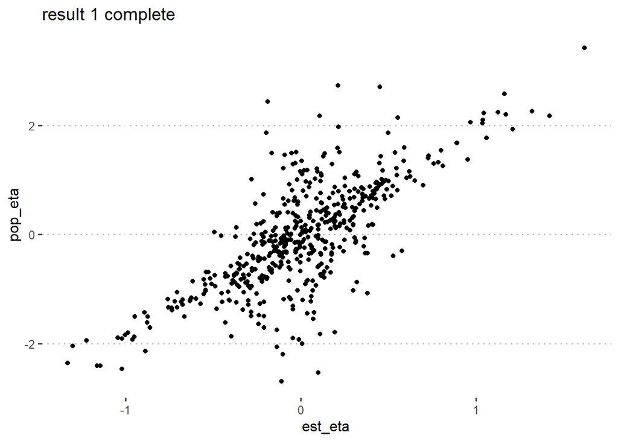

```
##             b00      b0       b1     a1     by1    by2    bu1     bu2
## true  0.0006775 0.02384 -0.08644 0.1245 -0.3414 0.1912 0.2984 -0.2942
## est  -0.0140564 0.03985 -0.20430 0.3005 -0.3463 0.2076 0.1541 -0.1994
```

#### 2

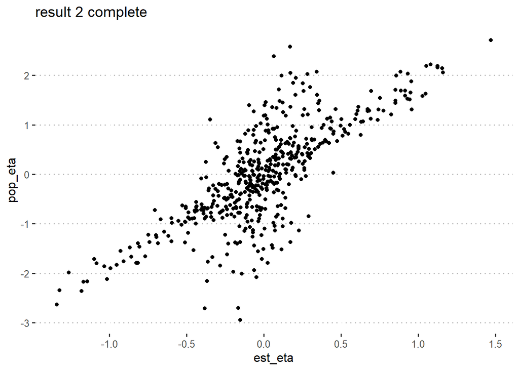

```
##           b00     b0      b1     a1     by1    by2    bu1     bu2
## true -0.03531 0.1998 0.03042 0.1067 -0.2619 0.3639 0.3167 -0.3578
## est  -0.03647 0.2036 0.07121 0.1637 -0.2500 0.3550 0.1279 -0.1721
```

#### 3

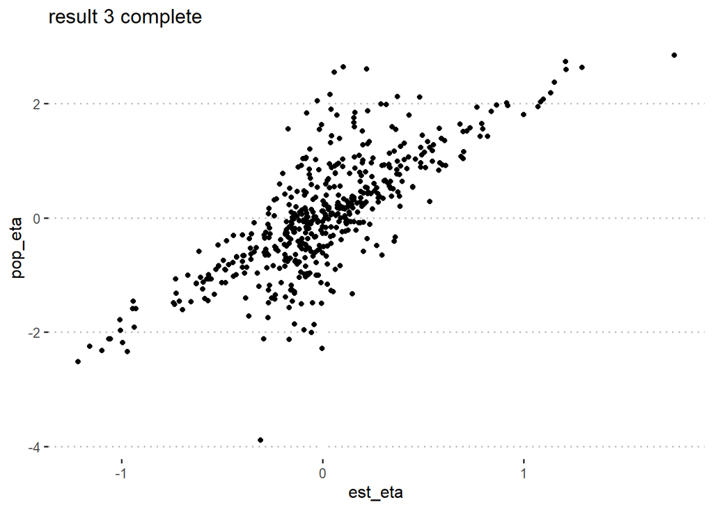

```
##          b00      b0      b1     a1     by1    by2    bu1     bu2
## true 0.01527 0.02020 0.07897 0.1602 -0.3237 0.3109 0.3553 -0.3304
## est  0.01679 0.03012 0.28761 0.1365 -0.3017 0.2890 0.1584 -0.1418
```

#### 4

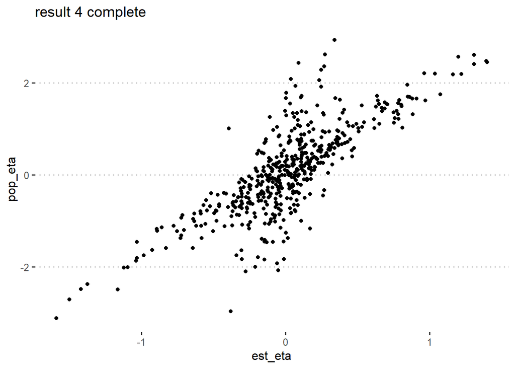

```
##           b00     b0       b1     a1     by1    by2    bu1     bu2
## true -0.05919 0.2428 -0.05300 0.2169 -0.2809 0.3596 0.3338 -0.2985
## est  -0.04976 0.2439 -0.06876 0.3248 -0.2580 0.3376 0.1410 -0.1261
```

#### 5

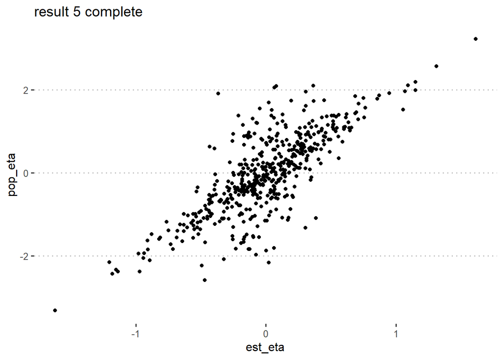

```
##          b00      b0      b1     a1     by1    by2    bu1     bu2
## true 0.04975 0.09605 -0.1471 0.2470 -0.2839 0.3522 0.3484 -0.2863
## est  0.04927 0.09272 -0.7545 0.9534 -0.2876 0.3753 0.1353 -0.1409
```

### 2PL

#### 1

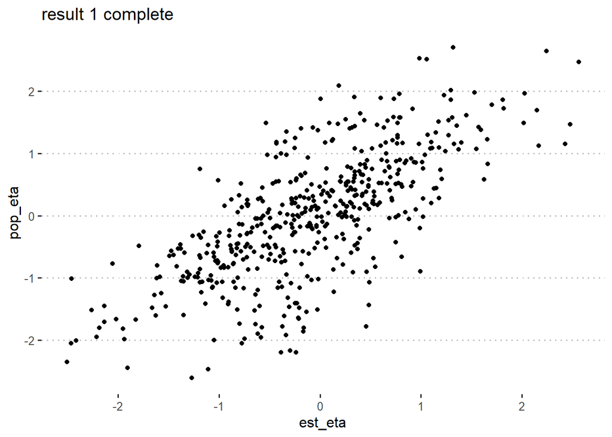

```
##          b00     b0       b1     a1     by1    by2    bu1     bu2
## true 0.01477 0.1771 -0.06296 0.1903 -0.3397 0.2616 0.2947 -0.3618
## est  0.01209 0.2029 -0.12150 0.2447 -0.3395 0.2893 0.2751 -0.4659
```

#### 2

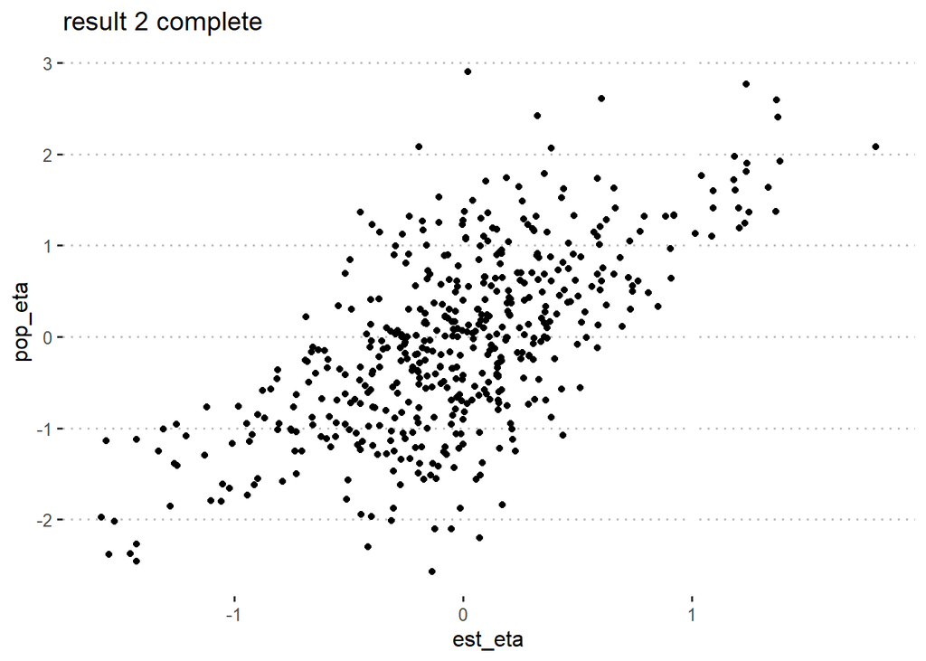

```
##          b00     b0       b1      a1     by1    by2    bu1     bu2
## true 0.02634 0.1253 -0.07953  0.1987 -0.3129 0.2946 0.2747 -0.3267
## est  0.01791 0.1350  0.25435 -0.1448 -0.2685 0.2399 0.2055 -0.1901
```

#### 3

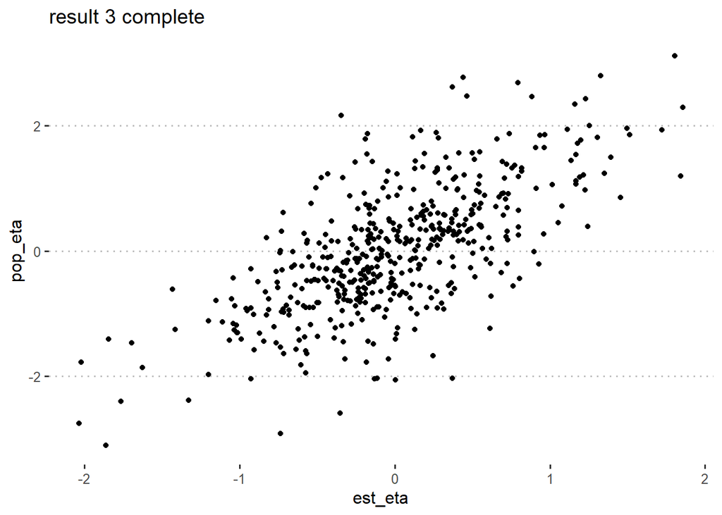

```
##           b00     b0       b1     a1     by1    by2    bu1     bu2
## true 0.004796 0.1673 -0.05776 0.1938 -0.3581 0.2877 0.3442 -0.2515
## est  0.007577 0.1655 -0.19980 0.3574 -0.3812 0.2910 0.3152 -0.1789
```

#### 4

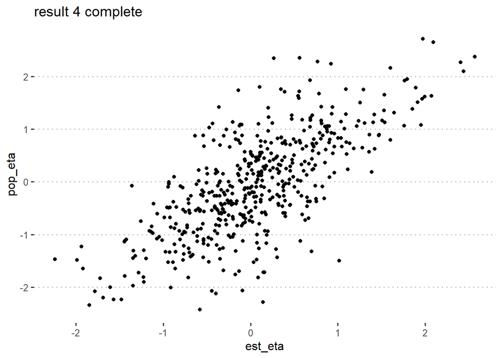

```
##          b00     b0      b1     a1     by1    by2    bu1     bu2
## true 0.03789 0.1308 -0.0831 0.2242 -0.3590 0.2715 0.2332 -0.3245
## est  0.02587 0.1193 -0.1798 0.3107 -0.3623 0.2912 0.2266 -0.3671
```

#### 5

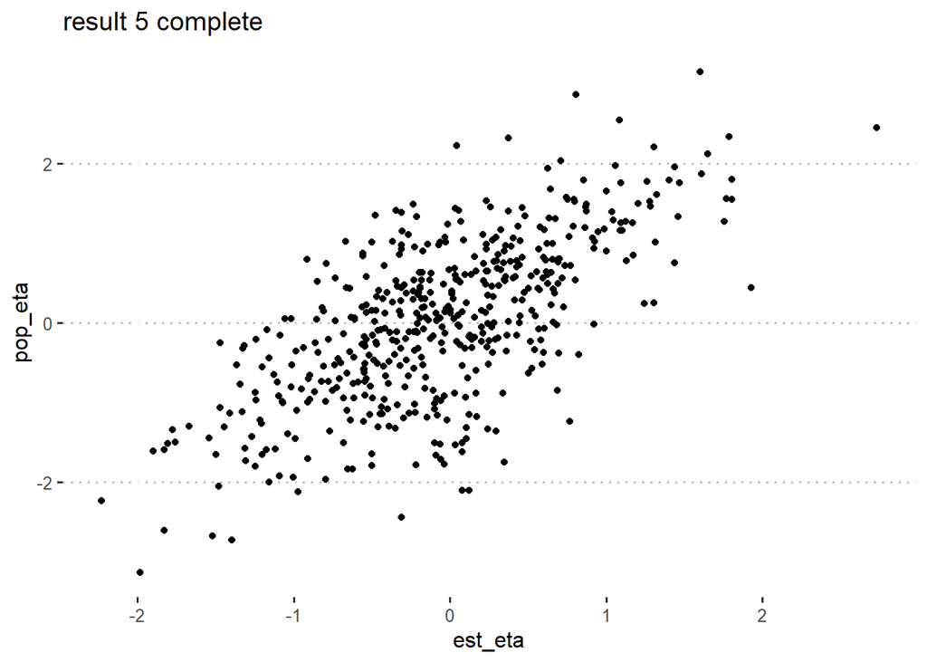

```
##          b00      b0       b1     a1     by1    by2    bu1     bu2
## true 0.07719 0.04944 -0.01007 0.1774 -0.3332 0.2424 0.4155 -0.2341
## est  0.06814 0.09845  0.03612 0.1471 -0.3345 0.2561 0.4275 -0.3334
```

### GPCM

#### 1

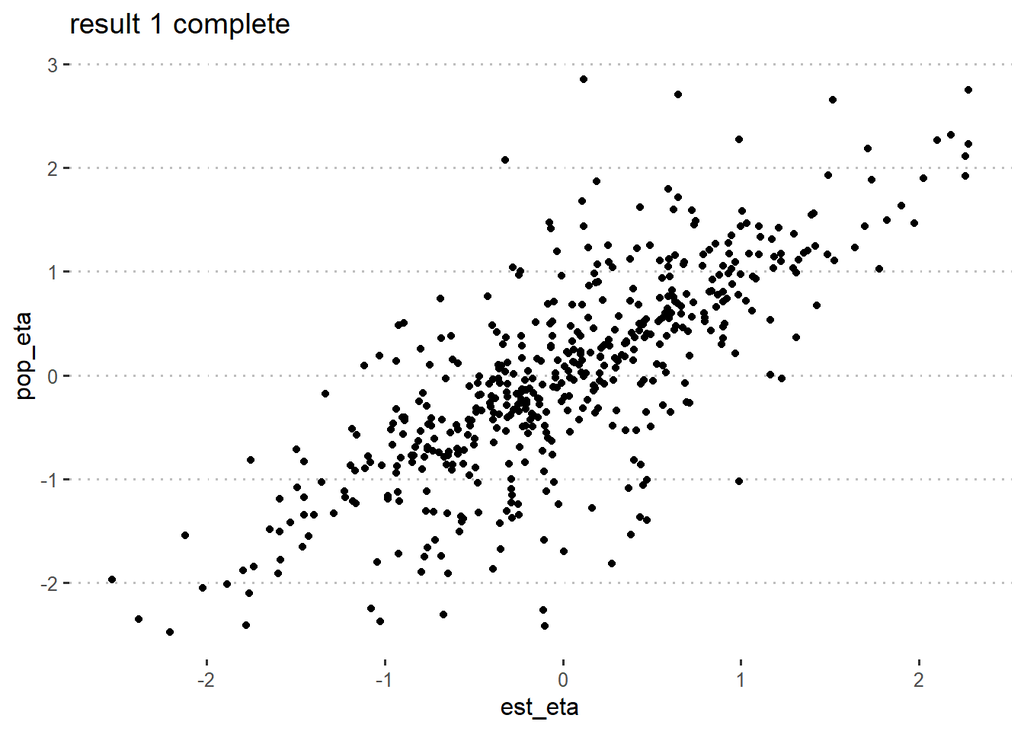

```
##          b00     b0      b1     a1     by1    by2    bu1     bu2
## true 0.06597 0.1327 0.05671 0.1605 -0.3382 0.3362 0.3710 -0.3348
## est  0.06356 0.1343 0.06945 0.1517 -0.3572 0.3248 0.4682 -0.3341
```

#### 2

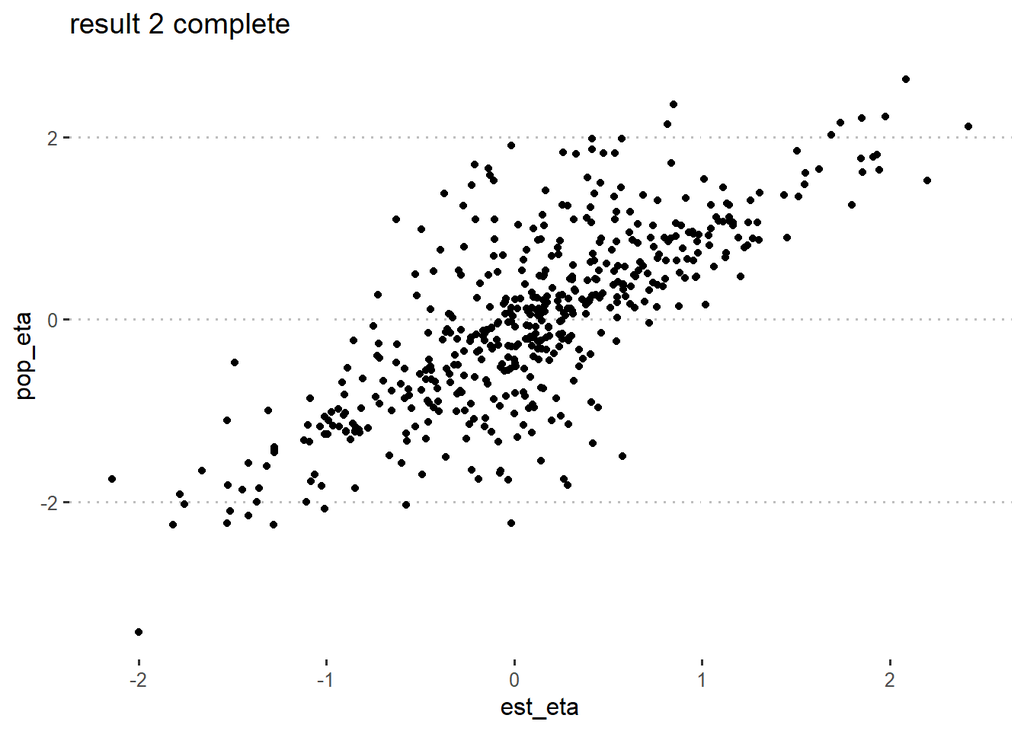

```
##            b00      b0       b1     a1     by1    by2    bu1     bu2
## true  0.001936 0.06917 -0.20027 0.2904 -0.3493 0.2969 0.3111 -0.2856
## est  -0.003727 0.05587 -0.07936 0.1768 -0.3207 0.2914 0.2631 -0.3133
```

#### 3

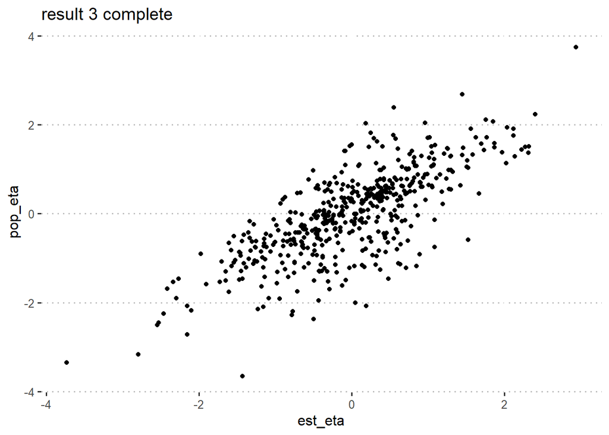

```
##            b00     b0      b1     a1     by1    by2    bu1     bu2
## true  0.001437 0.2274 -0.1794 0.2534 -0.3035 0.3378 0.2813 -0.3585
## est  -0.021045 0.2511 -0.1410 0.2129 -0.3203 0.3419 0.3803 -0.4338
```

#### 4

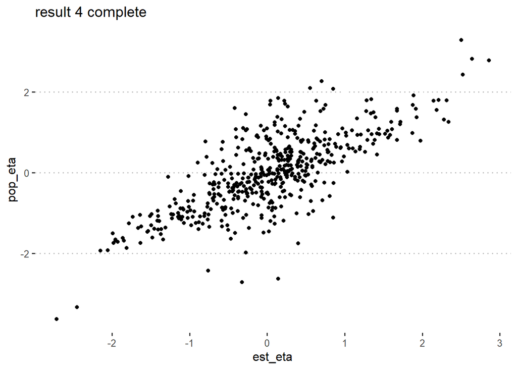

```
##           b00     b0       b1       a1     by1    by2    bu1     bu2
## true -0.03027 0.1382 -0.12696  0.19144 -0.2613 0.2740 0.2864 -0.3551
## est  -0.02096 0.1171  0.06674 -0.05059 -0.2250 0.2311 0.2644 -0.4983
```

#### 5

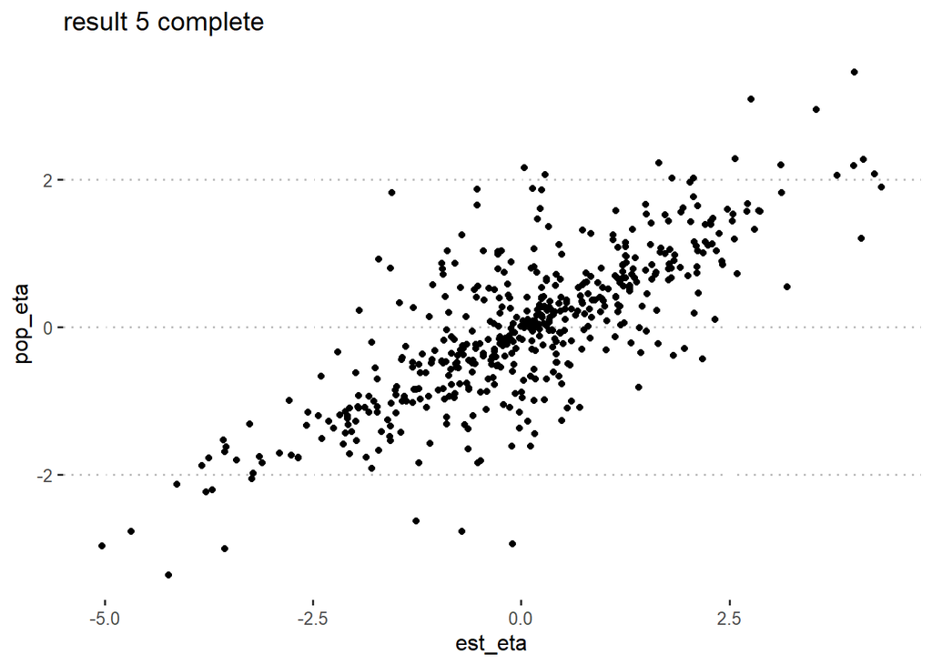

```
##           b00     b0       b1      a1     by1    by2    bu1     bu2
## true -0.02386 0.2481 -0.09639 0.22700 -0.2935 0.2774 0.3426 -0.3614
## est  -0.02846 0.2457  0.04911 0.02733 -0.2793 0.2603 0.7850 -0.7715
```

## LCA

I’ve tried specifying an LCA, but I don’t have an idea of how to incorporate the LCA into the FLPS. Below is the stan code I’ve tried.

I ran 10 replication with 2 latent classes and high class separation (.9 of item probability (y = 1) for the first class and .1 for the second class across all the indicators (10)).

Although the data is complete, the label switching occurred while sampling. You can see there is a clear bimodal distribution for the class proportion. Out of 10 replications, replication 7 and 8 showed the well-mixing results, and others showed the switched labels in the complete data case. There is only one replication (replication 9) showing well-mixing in the incomplete data case.

### stan code

```
## //https://discourse.mc-stan.org/t/latent-class-model-estimation-with-long-format-data/1799
## data {
##   int<lower=1> nsecWorked;                   // number of rows in long-format data
##   int<lower=1> nsec;                         // number of items
##   int<lower=1> nstud;                        // number of respondents
##
##   int<lower=1> studItem[nstud];
##   int<lower=0> cumStudItem[nstud];           // cummulative sum of item administred
##
##   int studentM[nsecWorked];  // student index for long-format data
##   int section[nsecWorked];    // item index for long-format data
##
##   int<lower=0,upper=1> grad[nsecWorked];      // long-format data
##
##   int<lower=1> nclass;                        // number of latent class
## }
##
## parameters {
##   simplex[nclass] nu;                          // overall class proportion
##   // real nu_logit[nclass];                    // overall class logit
##   real <lower = 0, upper = 1> p[nclass, nsec]; // probs of reponse = 1
##
##   // real class_logit[nstud] ;                 // individual class logits
## }
##
## //transformed parameters {
##   // int class_assign[nstud] ;                 // individual class assign
## //}
##
## model{
##   real ps[nclass];
##   vector[nclass] log_nu = log(nu);
##
##   for (j in 1:nstud) {
##     int nitem_given = studItem[j];
##
##  for (c in 1:nclass) {
##
##    real log_items[nitem_given];
##
##    for (m in 1:nitem_given) {
##
##      int i = section[cumStudItem[j] + m];
##
##      log_items[m] = grad[cumStudItem[j] + m] * log(p[c,i]) + (1 - grad[cumStudItem[j] + m]) * log(1 - p[c,i]);
##
##      }
##
##         ps[c] = log_nu[c] + sum(log_items);
##
##  }
##
##  target += log_sum_exp(ps);
##
##   }
## }
```

### Complete data

#### 1

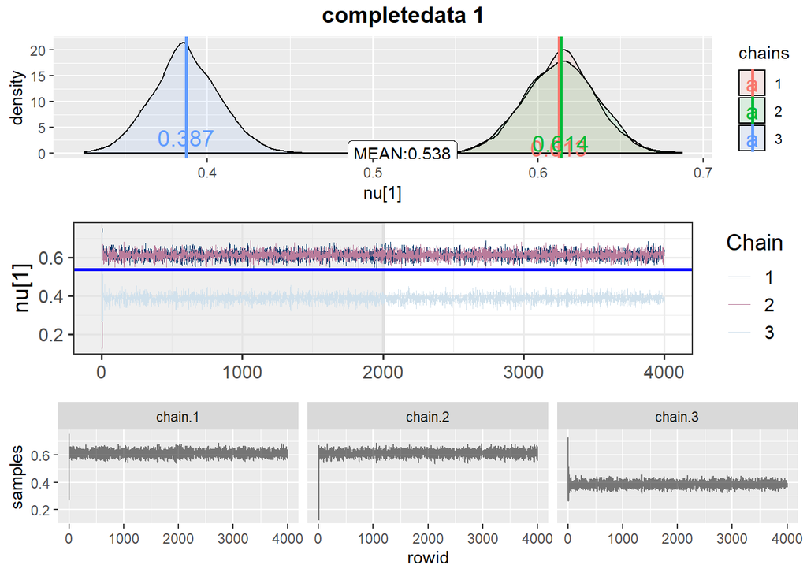

#### 2

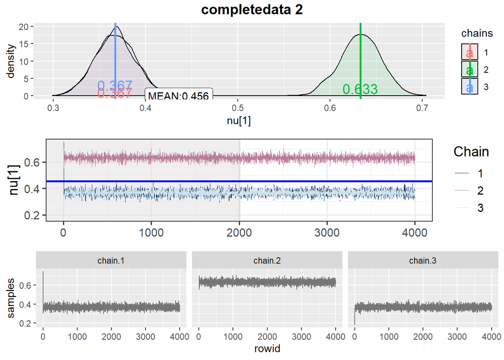

#### 3

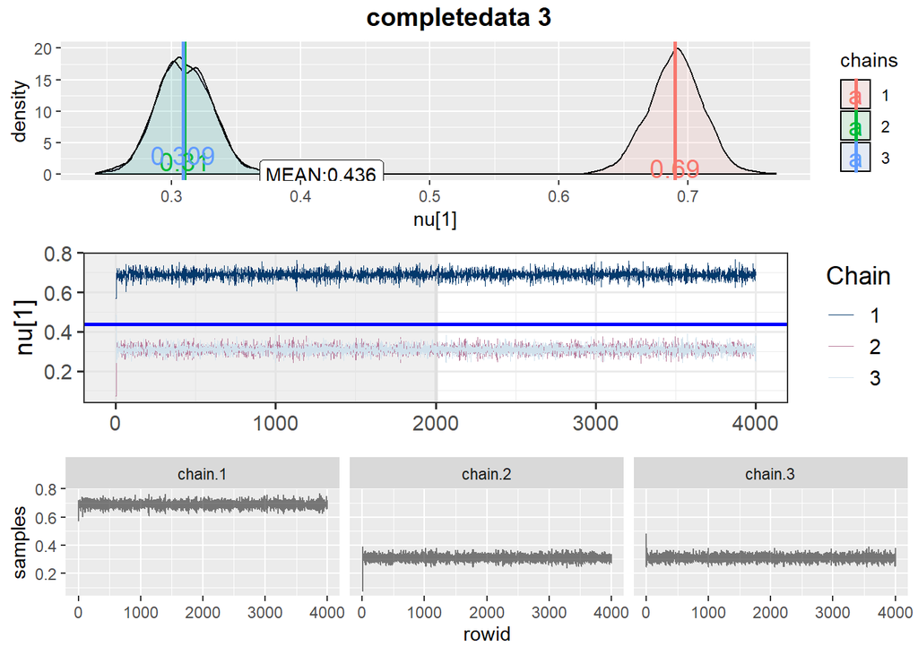

#### 4

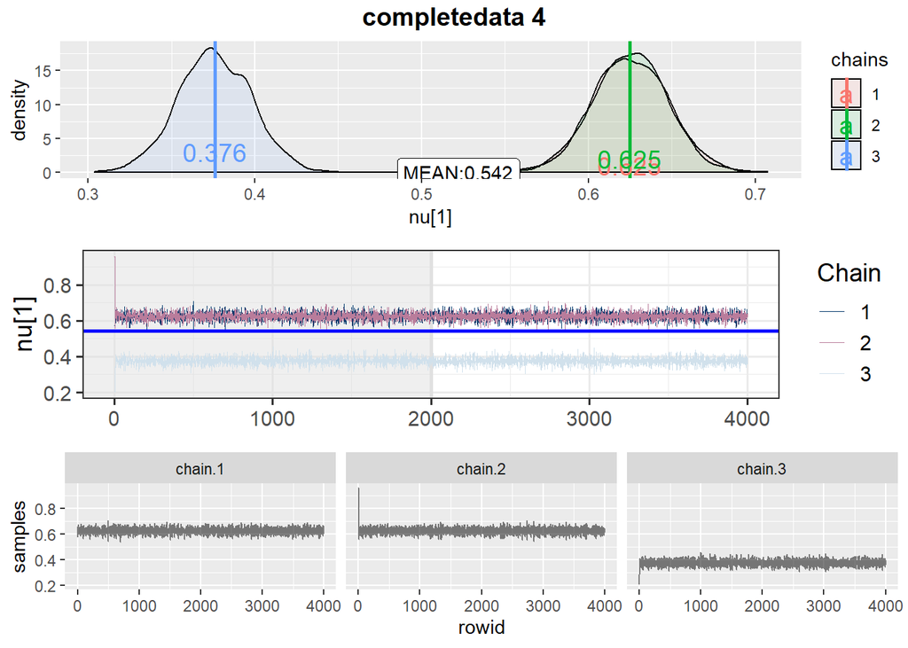

#### 5

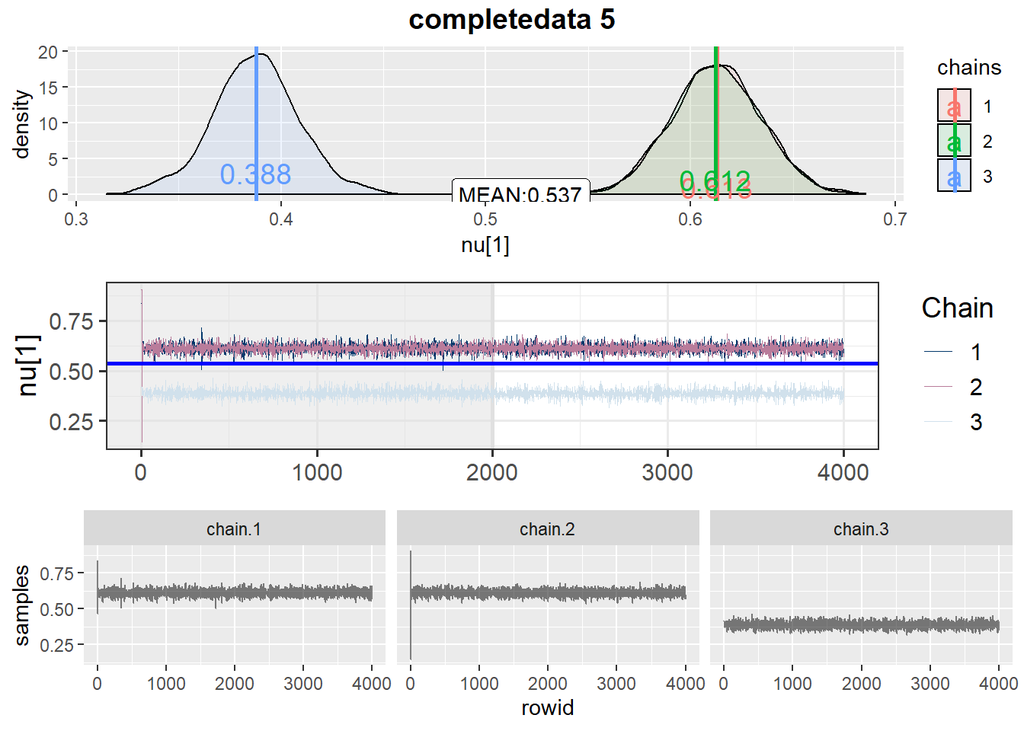

#### 6

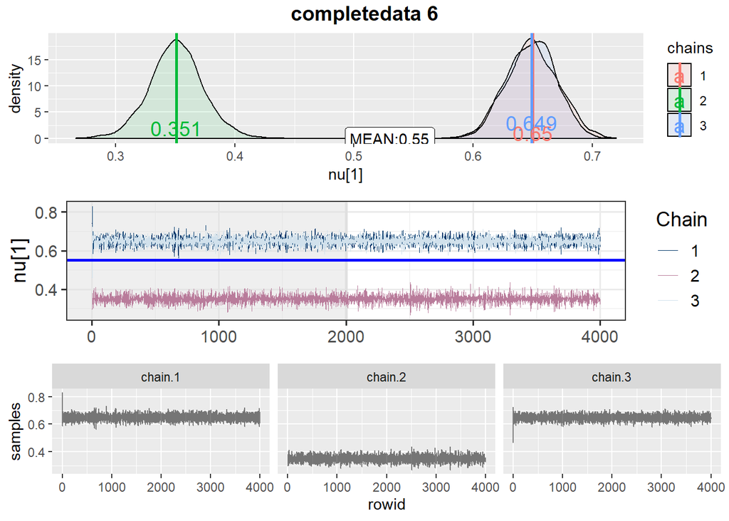

#### 7

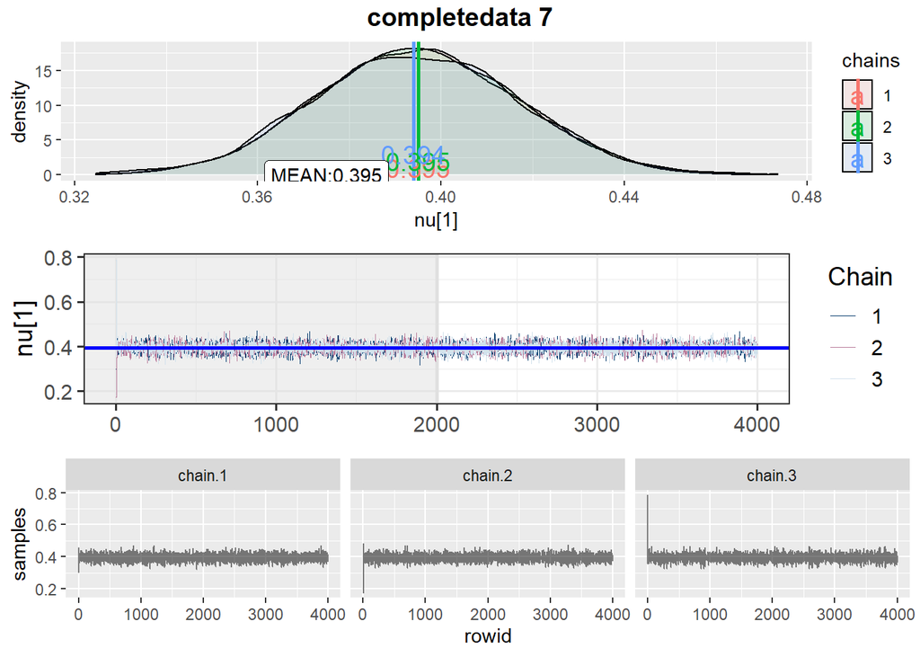

#### 8

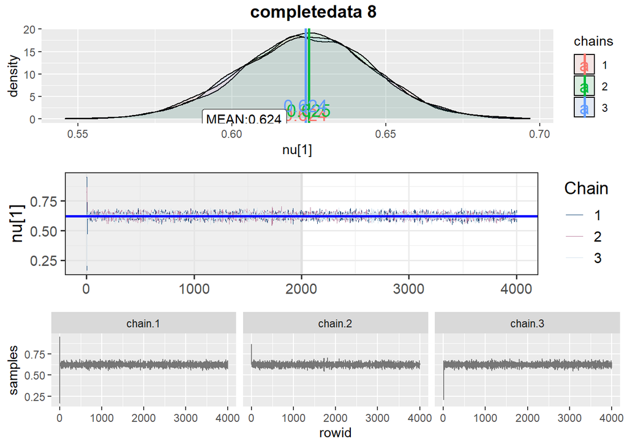

#### 9

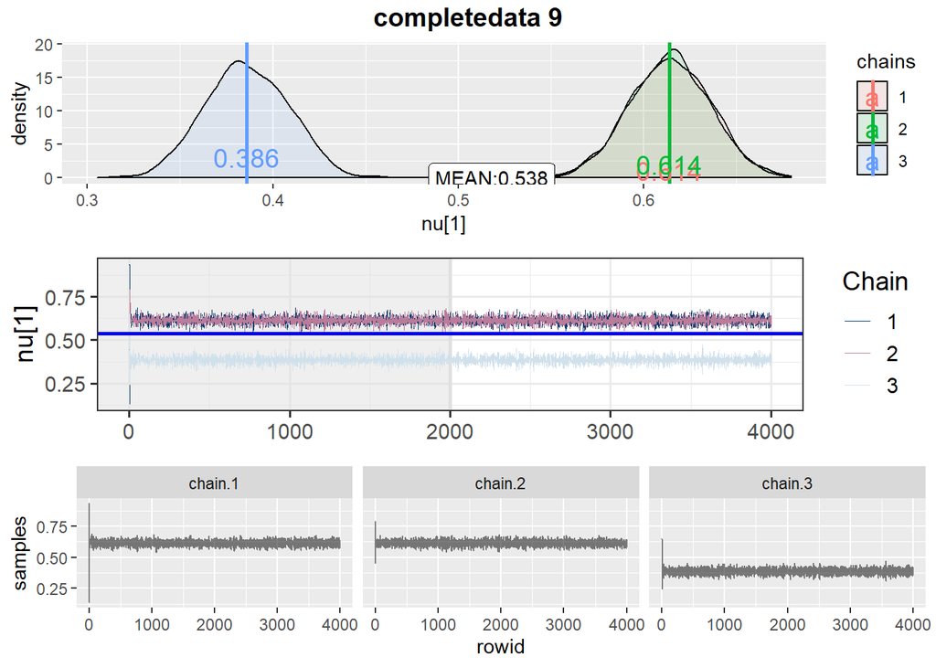

#### 10

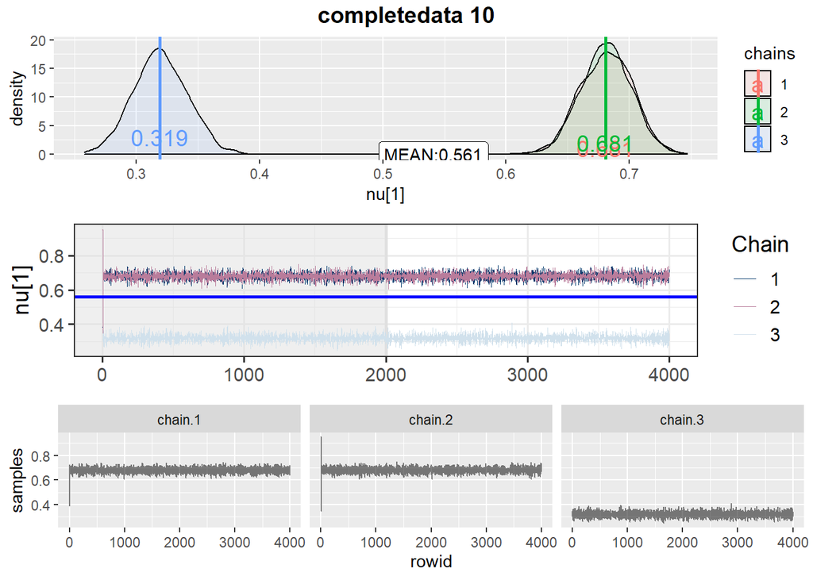

### Incomplete data

#### 1

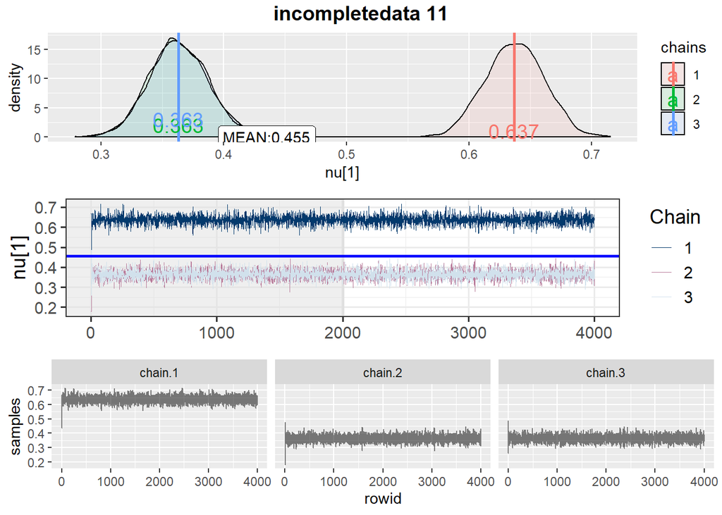

#### 2

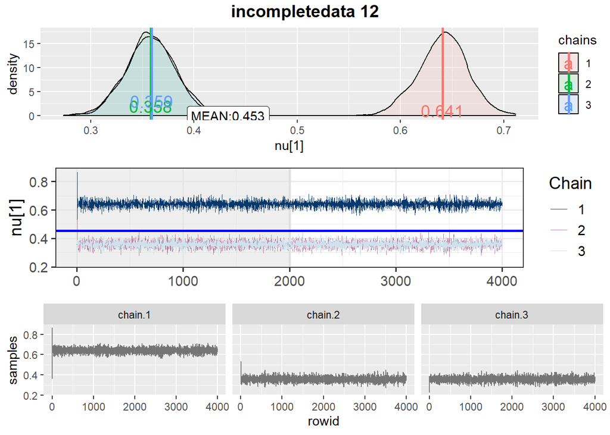

#### 3

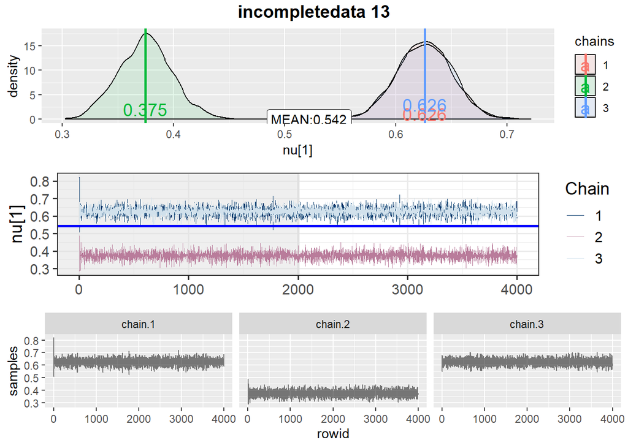

#### 4

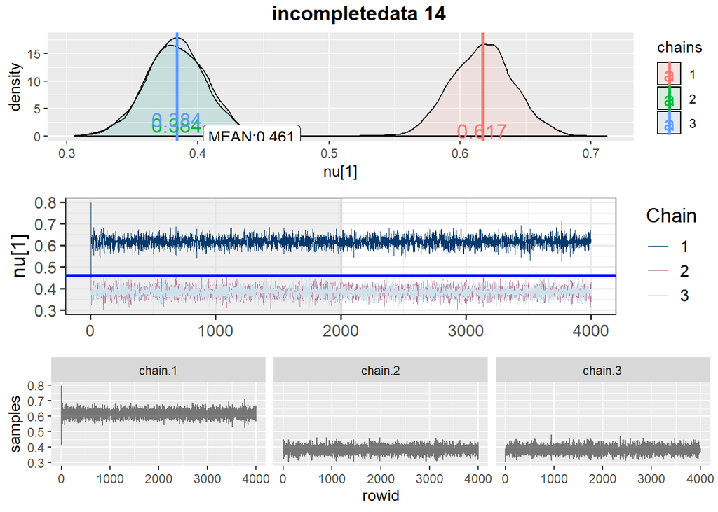

#### 5

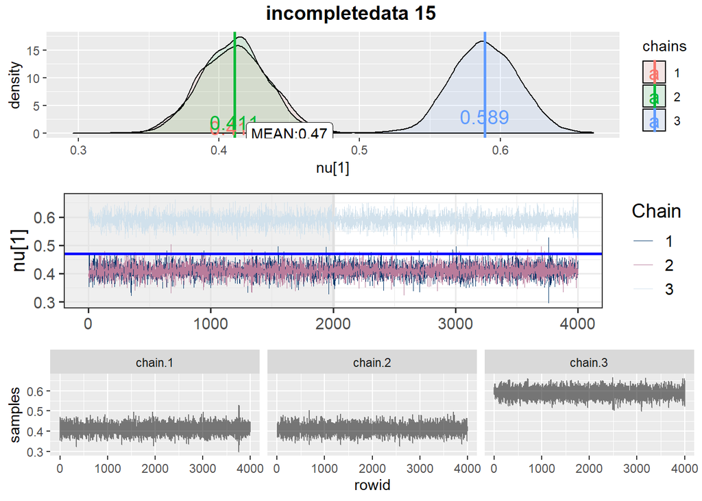

#### 6

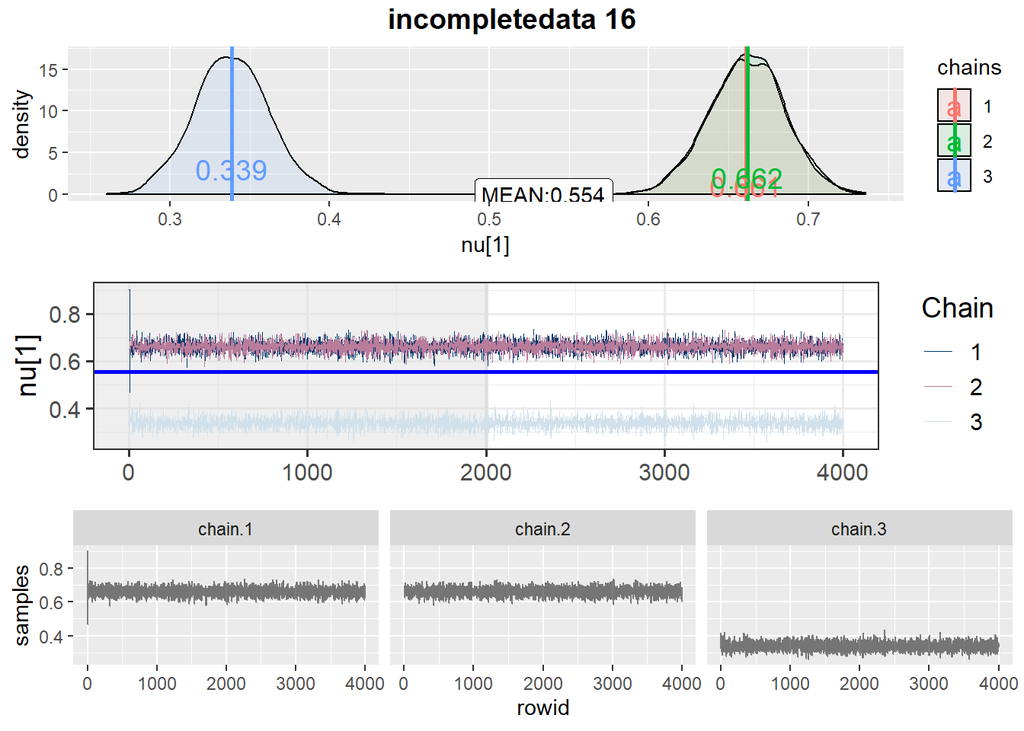

#### 7

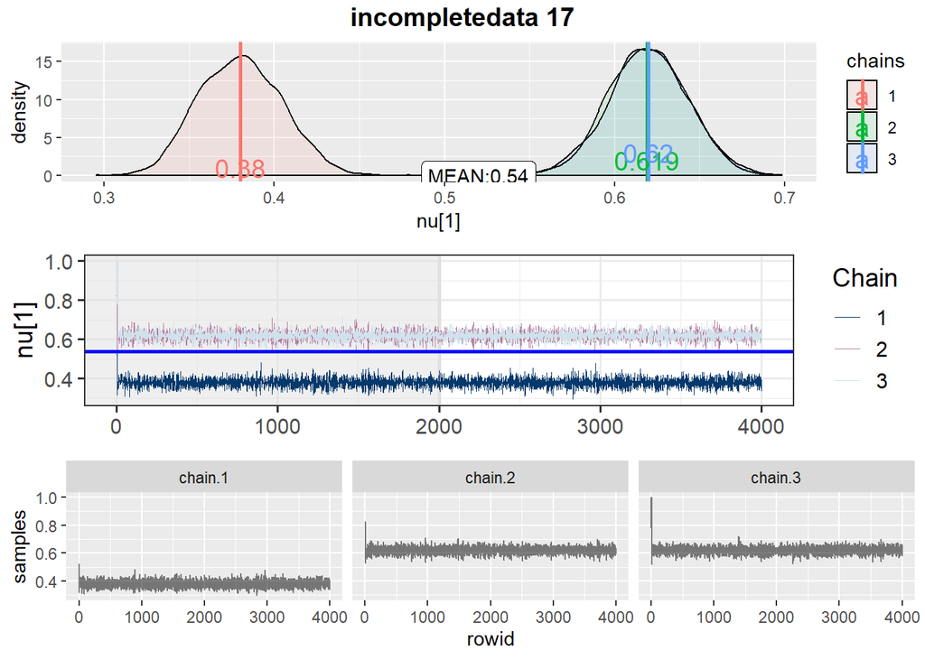

#### 8

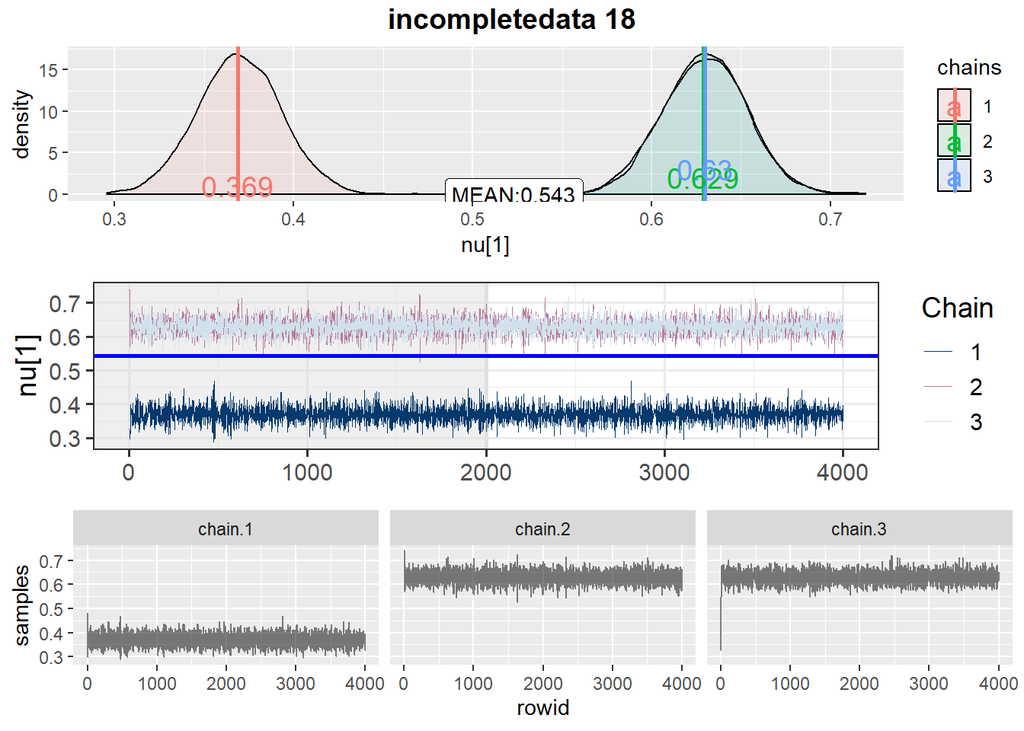

#### 9

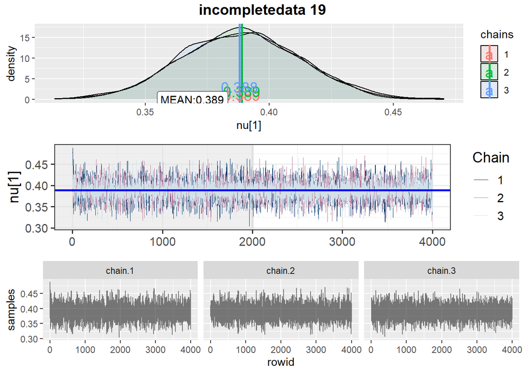

#### 10

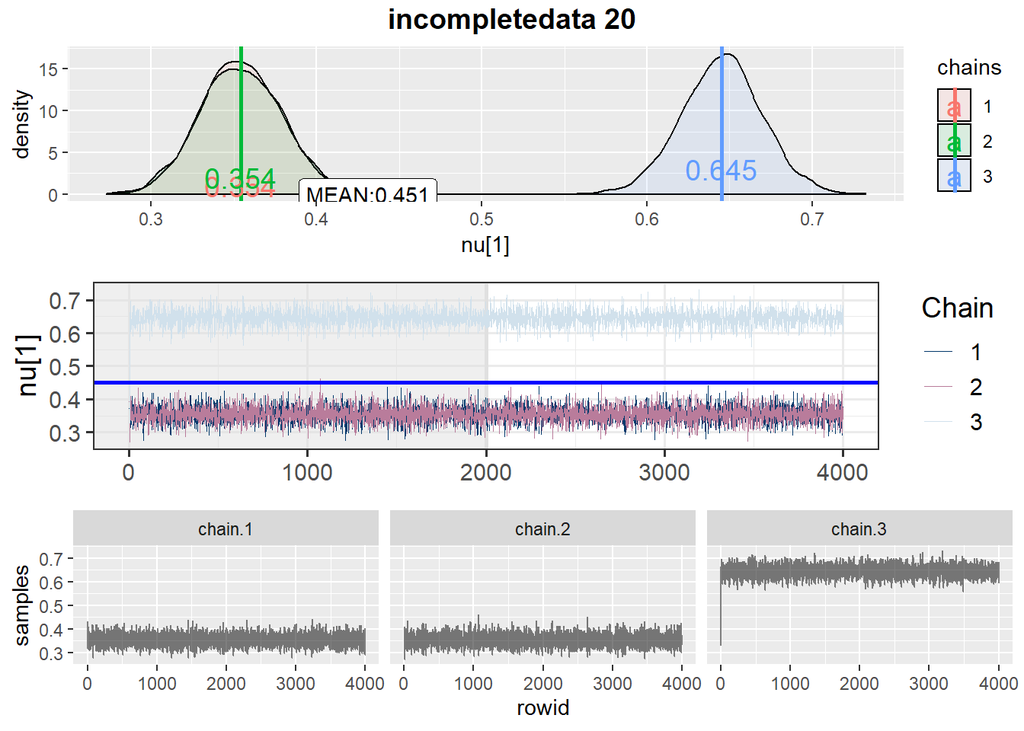